# Customer Feedback/Reviews - Lego on Amazon.com

The focus of this project is to find meaningful insights into popular LEGO products using customer reviews sourced from Amazon. The target audience would include LEGO enthusiasts, toy businesses, and marketers looking for consumer preferences and market trends in the LEGO industry.

### Purpose of Analysis

This analysis aims to:

- Guide LEGO fans in finding the most loved products.(Budget between 50 to 150.)
- Providing valuable insights into customer sentiment and product performance to business owners.
- Support marketers in refining their campaigns based on the analysis of sentiment and review trends.
- In leveraging such data, this study intends to empower strategic decision-making of key stakeholders in the LEGO marketplace.

## Business Questions

A number of key business questions can be identified based on the developed dataset, such as the following:

- What is the distribution of the overall rating?
- Which dates have the highest number of reviews?
- What are the common themes found in the reviews?
- Which LEGO products were highest rated?
- What is the average rating of LEGO sets in different periods?
- Who are the most active reviewers?
- What is the proportion of very positive or negative reviews?

```python
# run the following syntax and sign with your full name
input("Please sign the E-Signature (full name):")
```

```
Please sign the E-Signature (full name):Wei Xuan Hu
```

```
'Wei Xuan Hu'
```

```python
# Set up the environment
import time
from selenium import webdriver
from webdriver_manager.chrome import ChromeDriverManager
from selenium.webdriver.support.ui import WebDriverWait as wait
import pandas as pd
```

```python
#Get Chrome driver
from selenium.webdriver.firefox.options import Options

options = Options()
options.add_argument('--disable-blink-features=AutomationControlled')

driver = webdriver.Chrome(options=options)
```

## Part 1: Web Scrapping from Amazon.com

1. Brand: LEGO
2. Price Range: US 50-150
3. Age Range: 14 Years and UP

```python
reviews_dic = {'Product': [], 'Price': [], 'Customer': [], 'Ratings': [], 'Date': [], 'Review_text': []}

driver.implicitly_wait(10)

for index, new_link in enumerate(new_review_links[:5]):

    product_name = product_df.iloc[index]['Product']
    product_price = product_df.iloc[index]['Price']

    driver.get(new_link)
    time.sleep(10)

    # Find all elements that match the XPath
    names = driver.find_elements("xpath", '//*[@class="a-profile-name"]')
    ratings = driver.find_elements("xpath", '//*[@class="a-size-base a-link-normal review-title a-color-base review-title-content a-text-bold"]/i/span')
    dates = driver.find_elements("xpath", '//*[@class="a-size-base a-color-secondary review-date"]')
    reviews = driver.find_elements("xpath", '//*[@class="a-expander-content reviewText review-text-content a-expander-partial-collapse-content"]/span')

    # Iterate over each element to get its text content
    for name, rating, date, review in zip(names, ratings, dates, reviews):
        reviews_dic["Product"].append(product_name)
        reviews_dic["Price"].append(product_price)
        reviews_dic["Customer"].append(name.get_attribute('textContent').strip())
        reviews_dic['Ratings'].append(rating.get_attribute('textContent').strip())
        reviews_dic['Date'].append(date.get_attribute('textContent').strip())
        reviews_dic['Review_text'].append(review.get_attribute('textContent').strip())

print("Data collection is done!")
```

```
Data collection is done!
```

```python
# save the data in Pandas
product_df = pd.DataFrame(product_dic)
product_df.head()
```

|  | Product | Ratings | Price | Product_url | Review_url |
| --- | --- | --- | --- | --- | --- |
| 0 | Monster Fighters 9462 The Mummy | 3.9 out of 5 stars | $65.99 | https://www.amazon.com/LEGO-Monster-Fighters-M... | https://www.amazon.com/LEGO-Monster-Fighters-M... |
| 1 | Anna & Kristoff’s Sleigh Adventure #41066 | 4.6 out of 5 stars | $69.99 | https://www.amazon.com/LEGO-3-Pack-Action-Figu... | https://www.amazon.com/Lego-Kristoffs-Sleigh-A... |
| 2 | Star Wars 3-Pack Mech Action Figure Set 66778 ... | 4.6 out of 5 stars | $68.51 | https://www.amazon.com/LEGO-75880-Champions-Mc... | https://www.amazon.com/LEGO-3-Pack-Action-Figu... |
| 3 | Speed Champions 6175271 75880 Speed Champions ... | 4.7 out of 5 stars | $78.64 | https://www.amazon.com/LEGO-Jurassic-Tricerato... | https://www.amazon.com/LEGO-75880-Champions-Mc... |
| 4 | Jurassic World Dino Combo Pack 2 in 1 Tricerat... | 5.0 out of 5 stars | $69.90 | https://www.amazon.com/Eiffel-Figurine-Artwork... | https://www.amazon.com/LEGO-Jurassic-Tricerato... |

```python
# keep the number in Ratings column

product_df['Ratings'] = product_df['Ratings'].str.extract(r'(\d+\.\d+)').astype(float)

product_df['Ratings'].head()
```

```
0    3.9
1    4.6
2    4.6
3    4.7
4    5.0
Name: Ratings, dtype: float64
```

```python
product_df['Price'] = product_df['Price'].str.replace(r'[\$,]', '', regex=True).astype(float)
```

```python
# Convert Ratings to numeric
product_df['Ratings'] = pd.to_numeric(product_df['Ratings'], errors='coerce')

product_df.info()
```

```
<class 'pandas.core.frame.DataFrame'>
RangeIndex: 112 entries, 0 to 111
Data columns (total 5 columns):
 #   Column       Non-Null Count  Dtype
---  ------       --------------  -----
 0   Product      112 non-null    object
 1   Ratings      112 non-null    float64
 2   Price        112 non-null    float64
 3   Product_url  112 non-null    object
 4   Review_url   112 non-null    object
dtypes: float64(2), object(3)
memory usage: 4.5+ KB
```

### Filter for the Ratings bigger than 4.5

```python
filtered_df1 = product_df[product_df['Ratings'] > 4.5]
filtered_df1
```

|  | Product | Ratings | Price | Product_url | Review_url |
| --- | --- | --- | --- | --- | --- |
| 1 | Anna & Kristoff’s Sleigh Adventure #41066 | 4.6 | 69.99 | https://www.amazon.com/LEGO-3-Pack-Action-Figure-66778/dp/B0CK7Y66NZ/ref=sr_1_27?crid=33GLMMT8M6FPL&dib=eyJ2IjoiMSJ9.jH2BYrJPhHOkIbXHX3J4r_qmK9iPx-WGH4zNjkKu0LPFvCzXA-YMIvFXcBU7r_-jZJcDTNGI9m2OoVsmJ70… | https://www.amazon.com/Lego-Kristoffs-Sleigh-Adventure-41066/dp/B012NOL0ZE/ref=sr_1_26?crid=33GLMMT8M6FPL&dib=eyJ2IjoiMSJ9.jH2BYrJPhHOkIbXHX3J4r_qmK9iPx-WGH4zNjkKu0LPFvCzXA-YMIvFXcBU7r_-jZJcDTNGI9m2Oo… |
| 2 | Star Wars 3-Pack Mech Action Figure Set 66778 (432 Pieces) | 4.6 | 68.51 | https://www.amazon.com/LEGO-75880-Champions-McLaren-Building/dp/B06VVH7ZH6/ref=sr_1_28?crid=33GLMMT8M6FPL&dib=eyJ2IjoiMSJ9.jH2BYrJPhHOkIbXHX3J4r_qmK9iPx-WGH4zNjkKu0LPFvCzXA-YMIvFXcBU7r_-jZJcDTNGI9m2Oo… | https://www.amazon.com/LEGO-3-Pack-Action-Figure-66778/dp/B0CK7Y66NZ/ref=sr_1_27?crid=33GLMMT8M6FPL&dib=eyJ2IjoiMSJ9.jH2BYrJPhHOkIbXHX3J4r_qmK9iPx-WGH4zNjkKu0LPFvCzXA-YMIvFXcBU7r_-jZJcDTNGI9m2OoVsmJ70… |
| 3 | Speed Champions 6175271 75880 Speed Champions McLaren 720S Building Toy (161 Piece), Orange/Black, Multi | 4.7 | 78.64 | https://www.amazon.com/LEGO-Jurassic-Triceratops-Velociraptor-391pcs/dp/B0CKL2XPJL/ref=sr_1_29?crid=33GLMMT8M6FPL&dib=eyJ2IjoiMSJ9.jH2BYrJPhHOkIbXHX3J4r_qmK9iPx-WGH4zNjkKu0LPFvCzXA-YMIvFXcBU7r_-jZJcDT… | https://www.amazon.com/LEGO-75880-Champions-McLaren-Building/dp/B06VVH7ZH6/ref=sr_1_28?crid=33GLMMT8M6FPL&dib=eyJ2IjoiMSJ9.jH2BYrJPhHOkIbXHX3J4r_qmK9iPx-WGH4zNjkKu0LPFvCzXA-YMIvFXcBU7r_-jZJcDTNGI9m2Oo… |
| 4 | Jurassic World Dino Combo Pack 2 in 1 Triceratops and Velociraptor Gift Set (66774, 391pcs) | 5.0 | 69.90 | https://www.amazon.com/Eiffel-Figurine-Artwork-Collectors-%C3%AF%C2%BC%CB%86Black/dp/B00NVDJ7G6/ref=sr_1_30?crid=33GLMMT8M6FPL&dib=eyJ2IjoiMSJ9.jH2BYrJPhHOkIbXHX3J4r_qmK9iPx-WGH4zNjkKu0LPFvCzXA-YMIvFX… | https://www.amazon.com/LEGO-Jurassic-Triceratops-Velociraptor-391pcs/dp/B0CKL2XPJL/ref=sr_1_29?crid=33GLMMT8M6FPL&dib=eyJ2IjoiMSJ9.jH2BYrJPhHOkIbXHX3J4r_qmK9iPx-WGH4zNjkKu0LPFvCzXA-YMIvFXcBU7r_-jZJcDT… |
| 5 | ZOVIE Eiffel Tower for Cake Topper Decor and Home Party Decor -Great Figurine Artwork Gift for statue Collectors ï¼ˆBlack 7 Inch) | 4.6 | 69.95 | https://www.amazon.com/LEGO-Lego-40596-Magic-Maze/dp/B0CK743R3V/ref=sr_1_31?crid=33GLMMT8M6FPL&dib=eyJ2IjoiMSJ9.jH2BYrJPhHOkIbXHX3J4r_qmK9iPx-WGH4zNjkKu0LPFvCzXA-YMIvFXcBU7r_-jZJcDTNGI9m2OoVsmJ70aLylh… | https://www.amazon.com/Eiffel-Figurine-Artwork-Collectors-%C3%AF%C2%BC%CB%86Black/dp/B00NVDJ7G6/ref=sr_1_30?crid=33GLMMT8M6FPL&dib=eyJ2IjoiMSJ9.jH2BYrJPhHOkIbXHX3J4r_qmK9iPx-WGH4zNjkKu0LPFvCzXA-YMIvFX… |
| ... | ... | ... | ... | ... | ... |
| 104 | Agents Swamp Raid | 4.9 | 69.99 | https://www.amazon.com/LEGO-Technic-WHACK-42072-Building/dp/B075QYRTXZ/ref=sr_1_38?crid=33GLMMT8M6FPL&dib=eyJ2IjoiMSJ9.jH2BYrJPhHOkIbXHX3J4r_qmK9iPx-WGH4zNjkKu0LPFvCzXA-YMIvFXcBU7r_-jZJcDTNGI9m2OoVsmJ… | https://www.amazon.com/LEGO-8632-Agents-Swamp-Raid/dp/B001609BGW/ref=sr_1_33?crid=33GLMMT8M6FPL&dib=eyJ2IjoiMSJ9.jH2BYrJPhHOkIbXHX3J4r_qmK9iPx-WGH4zNjkKu0LPFvCzXA-YMIvFXcBU7r_-jZJcDTNGI9m2OoVsmJ70aLyl… |
| 107 | World Racers 8863 Snow Storm in Antarctica | 4.6 | 74.90 | https://www.amazon.com/Lego-Super-Heroes-Iron-Man/dp/B01JU4TCW8/ref=sr_1_43?crid=33GLMMT8M6FPL&dib=eyJ2IjoiMSJ9.jH2BYrJPhHOkIbXHX3J4r_qmK9iPx-WGH4zNjkKu0LPFvCzXA-YMIvFXcBU7r_-jZJcDTNGI9m2OoVsmJ70aLylh… | https://www.amazon.com/LEGO-Star-Wars-Imperial-Trooper/dp/B01CCT38EQ/ref=sr_1_37?crid=33GLMMT8M6FPL&dib=eyJ2IjoiMSJ9.jH2BYrJPhHOkIbXHX3J4r_qmK9iPx-WGH4zNjkKu0LPFvCzXA-YMIvFXcBU7r_-jZJcDTNGI9m2OoVsmJ70… |
| 108 | Star Wars 75121 Imperial Death Trooper™ | 4.7 | 82.95 | https://www.amazon.com/LEGO-Speed-Champions-quattro-75872/dp/B012NOLKHW/ref=sr_1_44?crid=33GLMMT8M6FPL&dib=eyJ2IjoiMSJ9.jH2BYrJPhHOkIbXHX3J4r_qmK9iPx-WGH4zNjkKu0LPFvCzXA-YMIvFXcBU7r_-jZJcDTNGI9m2OoVsm… | https://www.amazon.com/LEGO-Technic-WHACK-42072-Building/dp/B075QYRTXZ/ref=sr_1_38?crid=33GLMMT8M6FPL&dib=eyJ2IjoiMSJ9.jH2BYrJPhHOkIbXHX3J4r_qmK9iPx-WGH4zNjkKu0LPFvCzXA-YMIvFXcBU7r_-jZJcDTNGI9m2OoVsmJ… |
| 109 | Technic WHACK! 42072 Building Kit with Pull Back Toy Stunt Car, Popular Girls and Boys Engineering Toy for Creative Play (135 Pieces) | 4.6 | 82.88 | https://www.amazon.com/LEGO-NINJAGO-Katana-70638-Building/dp/B075R94T1T/ref=sr_1_45?crid=33GLMMT8M6FPL&dib=eyJ2IjoiMSJ9.jH2BYrJPhHOkIbXHX3J4r_qmK9iPx-WGH4zNjkKu0LPFvCzXA-YMIvFXcBU7r_-jZJcDTNGI9m2OoVsm… | https://www.amazon.com/LEGO-Stories-Action-Vikings-Challenges/dp/B0007ZCJ0M/ref=sr_1_39?crid=33GLMMT8M6FPL&dib=eyJ2IjoiMSJ9.jH2BYrJPhHOkIbXHX3J4r_qmK9iPx-WGH4zNjkKu0LPFvCzXA-YMIvFXcBU7r_-jZJcDTNGI9m2O… |
| 111 | Movie 70804 Ice Cream Machine | 4.6 | 78.99 | https://www.amazon.com/LEGO-Perseverance-Ingenuity-Helicopter-Engineering/dp/B0BSRD2CXY/ref=sr_1_48?crid=33GLMMT8M6FPL&dib=eyJ2IjoiMSJ9.jH2BYrJPhHOkIbXHX3J4r_qmK9iPx-WGH4zNjkKu0LPFvCzXA-YMIvFXcBU7r_-j… | https://www.amazon.com/LEGO-Ultra-Agents-70164-Hurricane/dp/B00J4S7AC0/ref=sr_1_41?crid=33GLMMT8M6FPL&dib=eyJ2IjoiMSJ9.jH2BYrJPhHOkIbXHX3J4r_qmK9iPx-WGH4zNjkKu0LPFvCzXA-YMIvFXcBU7r_-jZJcDTNGI9m2OoVsmJ… |

77 rows × 5 columns

### Get the reviews

```python
filtered_df1['Review_url']
```

```
1                           https://www.amazon.com/Lego-Kristoffs-Sleigh-Adventure-41066/dp/B012NOL0ZE/ref=sr_1_26?crid=33GLMMT8M6FPL&dib=eyJ2IjoiMSJ9.jH2BYrJPhHOkIbXHX3J4r_qmK9iPx-WGH4zNjkKu0LPFvCzXA-YMIvFXcBU7r_-jZJcDTNGI9m2OoVsmJ70aLylheg48cvdMRF8iBHoWt8cfGlntO_1AJ9rHEDJDWtUEiizD85N1wsiiW-3v-8j47…
2                                 https://www.amazon.com/LEGO-3-Pack-Action-Figure-66778/dp/B0CK7Y66NZ/ref=sr_1_27?crid=33GLMMT8M6FPL&dib=eyJ2IjoiMSJ9.jH2BYrJPhHOkIbXHX3J4r_qmK9iPx-WGH4zNjkKu0LPFvCzXA-YMIvFXcBU7r_-jZJcDTNGI9m2OoVsmJ70aLylheg48cvdMRF8iBHoWt8cfGlntO_1AJ9rHEDJDWtUEiizD85N1wsiiW-3v-8j47…
3                           https://www.amazon.com/LEGO-75880-Champions-McLaren-Building/dp/B06VVH7ZH6/ref=sr_1_28?crid=33GLMMT8M6FPL&dib=eyJ2IjoiMSJ9.jH2BYrJPhHOkIbXHX3J4r_qmK9iPx-WGH4zNjkKu0LPFvCzXA-YMIvFXcBU7r_-jZJcDTNGI9m2OoVsmJ70aLylheg48cvdMRF8iBHoWt8cfGlntO_1AJ9rHEDJDWtUEiizD85N1wsiiW-3v-8j47…
4                   https://www.amazon.com/LEGO-Jurassic-Triceratops-Velociraptor-391pcs/dp/B0CKL2XPJL/ref=sr_1_29?crid=33GLMMT8M6FPL&dib=eyJ2IjoiMSJ9.jH2BYrJPhHOkIbXHX3J4r_qmK9iPx-WGH4zNjkKu0LPFvCzXA-YMIvFXcBU7r_-jZJcDTNGI9m2OoVsmJ70aLylheg48cvdMRF8iBHoWt8cfGlntO_1AJ9rHEDJDWtUEiizD85N1wsiiW-3v-8j47…
5      https://www.amazon.com/Eiffel-Figurine-Artwork-Collectors-%C3%AF%C2%BC%CB%86Black/dp/B00NVDJ7G6/ref=sr_1_30?crid=33GLMMT8M6FPL&dib=eyJ2IjoiMSJ9.jH2BYrJPhHOkIbXHX3J4r_qmK9iPx-WGH4zNjkKu0LPFvCzXA-YMIvFXcBU7r_-jZJcDTNGI9m2OoVsmJ70aLylheg48cvdMRF8iBHoWt8cfGlntO_1AJ9rHEDJDWtUEiizD85N1wsiiW-3v-8j47…
                                                                                                                                                                                                                                                                                                            …
104                                   https://www.amazon.com/LEGO-8632-Agents-Swamp-Raid/dp/B001609BGW/ref=sr_1_33?crid=33GLMMT8M6FPL&dib=eyJ2IjoiMSJ9.jH2BYrJPhHOkIbXHX3J4r_qmK9iPx-WGH4zNjkKu0LPFvCzXA-YMIvFXcBU7r_-jZJcDTNGI9m2OoVsmJ70aLylheg48cvdMRF8iBHoWt8cfGlntO_1AJ9rHEDJDWtUEiizD85N1wsiiW-3v-8j47…
107                               https://www.amazon.com/LEGO-Star-Wars-Imperial-Trooper/dp/B01CCT38EQ/ref=sr_1_37?crid=33GLMMT8M6FPL&dib=eyJ2IjoiMSJ9.jH2BYrJPhHOkIbXHX3J4r_qmK9iPx-WGH4zNjkKu0LPFvCzXA-YMIvFXcBU7r_-jZJcDTNGI9m2OoVsmJ70aLylheg48cvdMRF8iBHoWt8cfGlntO_1AJ9rHEDJDWtUEiizD85N1wsiiW-3v-8j47…
108                             https://www.amazon.com/LEGO-Technic-WHACK-42072-Building/dp/B075QYRTXZ/ref=sr_1_38?crid=33GLMMT8M6FPL&dib=eyJ2IjoiMSJ9.jH2BYrJPhHOkIbXHX3J4r_qmK9iPx-WGH4zNjkKu0LPFvCzXA-YMIvFXcBU7r_-jZJcDTNGI9m2OoVsmJ70aLylheg48cvdMRF8iBHoWt8cfGlntO_1AJ9rHEDJDWtUEiizD85N1wsiiW-3v-8j47…
109                        https://www.amazon.com/LEGO-Stories-Action-Vikings-Challenges/dp/B0007ZCJ0M/ref=sr_1_39?crid=33GLMMT8M6FPL&dib=eyJ2IjoiMSJ9.jH2BYrJPhHOkIbXHX3J4r_qmK9iPx-WGH4zNjkKu0LPFvCzXA-YMIvFXcBU7r_-jZJcDTNGI9m2OoVsmJ70aLylheg48cvdMRF8iBHoWt8cfGlntO_1AJ9rHEDJDWtUEiizD85N1wsiiW-3v-8j47…
111                             https://www.amazon.com/LEGO-Ultra-Agents-70164-Hurricane/dp/B00J4S7AC0/ref=sr_1_41?crid=33GLMMT8M6FPL&dib=eyJ2IjoiMSJ9.jH2BYrJPhHOkIbXHX3J4r_qmK9iPx-WGH4zNjkKu0LPFvCzXA-YMIvFXcBU7r_-jZJcDTNGI9m2OoVsmJ70aLylheg48cvdMRF8iBHoWt8cfGlntO_1AJ9rHEDJDWtUEiizD85N1wsiiW-3v-8j47…
Name: Review_url, Length: 77, dtype: object
```

```python
# Initialize an empty list to store updated links
new_review_links = []

# Loop through each review link in the product_df
for link in filtered_df1["Review_url"]:

    # Split the link to remove the query parameters and session ID, if any
    base_link = link.split('/ref=')[0]
    session_id = link.split('/')[-1]

    # For each link, generate new links for each pageNumber in the range
    for i in range(1, 6):  # Generates 5 new URLs per original URL
        # Construct the new link with the updated ref part and append "?pageNumber=i"
        # example url:
        # {https://www.amazon.com/product-reviews/B0CP9Z56SW}/ref=cm_cr_arp_d_paging_btm_next_{2}/{140-2291549-5442769}?pageNumber={2}

        new_link = f"{base_link}/ref=zg_bs_g_kitchen_d_sccl_{i}_cr/{session_id}?pageNumber={i}"
        new_review_links.append(new_link)


# Now, new_review_links contains all the modified links
for new_link in new_review_links:
    print(new_link)
```

[output not shown]

[output cut: 368 more lines]

```python
len(new_review_links)
```

```
385
```

```python
reviews_dic = {'Product_url':[], 'Customer': [], 'Ratings': [], 'Date': [], 'Review_text': []}

driver.implicitly_wait(10)

for new_link in new_review_links:
    driver.get(new_link)
    time.sleep(10)

    # Find all elements that match the XPath
    names = driver.find_elements("xpath", '//*[@class="a-profile-name"]')
    ratings = driver.find_elements("xpath", '//*[@class="a-size-base a-link-normal review-title a-color-base review-title-content a-text-bold"]/i/span')
    dates = driver.find_elements("xpath", '//*[@class="a-size-base a-color-secondary review-date"]')
    reviews = driver.find_elements("xpath", '//*[@class="a-expander-content reviewText review-text-content a-expander-partial-collapse-content"]/span')
    product_urls = driver.find_element("xpath", '//*[@id="a-page"]/link[2]')

    # Iterate over each element to get its text content
    for name, rating, date, review in zip(names,ratings,dates,reviews):
        reviews_dic["Customer"].append(name.get_attribute('textContent').strip())
        reviews_dic['Ratings'].append(rating.get_attribute('textContent').strip())
        reviews_dic['Date'].append(date.get_attribute('textContent').strip())
        reviews_dic['Review_text'].append(review.get_attribute('textContent').strip())
        reviews_dic['Product_url'].append(product_urls.get_attribute('href'))

print("Data collection is done!")
```

```
Data collection is done!
```

```python
reviews_df = pd.DataFrame(reviews_dic)
reviews_df
```

|  | Product_url | Customer | Ratings | Date | Review_text |
| --- | --- | --- | --- | --- | --- |
| 0 | https://www.amazon.com/Lego-Kristoffs-Sleigh-Adventure-41066/dp/B012NOL0ZE | Amazon Customer | 5.0 out of 5 stars | Reviewed in the United States on February 7, 2018 | Item More than met expectations. Nothing but praise. |
| 1 | https://www.amazon.com/Lego-Kristoffs-Sleigh-Adventure-41066/dp/B012NOL0ZE | Doug Champagne | 5.0 out of 5 stars | Reviewed in the United States on February 7, 2016 | Bought as a gift. Love the gift. |
| 2 | https://www.amazon.com/Lego-Kristoffs-Sleigh-Adventure-41066/dp/B012NOL0ZE | Amazon Customer | 5.0 out of 5 stars | Reviewed in the United States on February 7, 2018 | Item More than met expectations. Nothing but praise. |
| 3 | https://www.amazon.com/Lego-Kristoffs-Sleigh-Adventure-41066/dp/B012NOL0ZE | Doug Champagne | 5.0 out of 5 stars | Reviewed in the United States on February 7, 2016 | Bought as a gift. Love the gift. |
| 4 | https://www.amazon.com/Lego-Kristoffs-Sleigh-Adventure-41066/dp/B012NOL0ZE | Amazon Customer | 5.0 out of 5 stars | Reviewed in the United States on February 7, 2018 | Item More than met expectations. Nothing but praise. |
| ... | ... | ... | ... | ... | ... |
| 1815 | https://www.amazon.com/LEGO-Ultra-Agents-70164-Hurricane/dp/B00J4S7AC0 | Roberta Franco | 5.0 out of 5 stars | Reviewed in the United States on November 7, 2018 | My six year old finished building it in 3 hours and lots of fun after that😊 |
| 1816 | https://www.amazon.com/LEGO-Ultra-Agents-70164-Hurricane/dp/B00J4S7AC0 | Jerry Newman | 5.0 out of 5 stars | Reviewed in the United States on July 22, 2015 | My son loved it! This is the biggest Lego set he has ever had and he waited a long time to "earn" it. My husband built most of it and he said it had some really cool parts he had never seen before. Th… |
| 1817 | https://www.amazon.com/LEGO-Ultra-Agents-70164-Hurricane/dp/B00J4S7AC0 | Nancy CA | 3.0 out of 5 stars | Reviewed in the United States on May 6, 2015 | This was complicated! You should know that the set's wind propellers are go stop go stop motion (go stop motion is when you spin it, it will go but if you let go really fast, it will stop). It's a pre… |
| 1818 | https://www.amazon.com/LEGO-Ultra-Agents-70164-Hurricane/dp/B00J4S7AC0 | Nancy CA | 5.0 out of 5 stars | Reviewed in the United States on June 6, 2017 | My grandson LOVES this set. He built it all by himself. Daddy tried to help but the Little Man was determined. It took him two evenings to finish it. The look on his face when it was done? Easily wort… |
| 1819 | https://www.amazon.com/LEGO-Ultra-Agents-70164-Hurricane/dp/B00J4S7AC0 | JMK | 4.0 out of 5 stars | Reviewed in the United States on February 22, 2015 | Classic |

1820 rows × 5 columns

```python
reviews_df['Ratings'] = reviews_df['Ratings'].apply(lambda x: float(x.split(" ")[0]))
reviews_df.info()
```

```
<class 'pandas.core.frame.DataFrame'>
RangeIndex: 1820 entries, 0 to 1819
Data columns (total 5 columns):
 #   Column       Non-Null Count  Dtype
---  ------       --------------  -----
 0   Product_url  1820 non-null   object
 1   Customer     1820 non-null   object
 2   Ratings      1820 non-null   float64
 3   Date         1820 non-null   object
 4   Review_text  1820 non-null   object
dtypes: float64(1), object(4)
memory usage: 71.2+ KB
```

## Part 2: Data cleasing

```python
# define the parts of speech function
from nltk.tag import pos_tag
from nltk.tokenize import word_tokenize
from nltk.stem import WordNetLemmatizer

# Initialize lemmatizer
lemmatizer = WordNetLemmatizer()

def nouns_adjs(text):
    text = text.lower()
    token_list = word_tokenize(text)

    # unwanted words set
    remove_words = {'t', 'vse', 'i', 'review', 'com', 'didn','don'}
    clean_text = [word for word in token_list if word not in remove_words]

    # label the parts of speech
    word_tag = pos_tag(clean_text)
    nouns_adjs_lists = [word for word, tag in word_tag if tag in ["NN", "NNP", "NNS", "JJ", "JJR", "JJS"]]

    # lemmatizing the nouns and adjectives
    lemma_words = [lemmatizer.lemmatize(word) for word in nouns_adjs_lists]

    nouns_adjs = ' '.join(lemma_words)

    return nouns_adjs
```

```python
# import the data and seperate the product reviews by the product name
# filter all the nouns and adjectives

reviews_df["Nouns_adjs"] = reviews_df["Review_text"].apply(nouns_adjs)
reviews_df.head()
```

[output not shown]

```python
import re

def clean_date(date_string):
    match = re.search(r'on ([a-zA-Z]+ \d{1,2}, \d{4})', date_string)
    if match:
        return pd.to_datetime(match.group(1), format='%B %d, %Y')
    return None

reviews_df['Cleaned_Date'] = reviews_df['Date'].apply(clean_date)
reviews_df['Year'] = reviews_df['Cleaned_Date'].dt.year

reviews_df
```

[output not shown]

1820 rows × 9 columns

```python
reviews_df.info()
```

[output not shown]

## Part 3: Data Analytics Section - Atleast 6 Questions

```
Top 20 Most Common Nouns and Adjectives: [('lego', 1540), ('set', 1085), ('car', 840), ('son', 455), ('gift', 420), ('great', 385), ('other', 385), ('year', 385), ('old', 350), ('grandson', 315), ('little', 315), ('good', 315), ('time', 280), ('fun', 245), ('bike', 245), ('viking', 245), ('price', 2…
```

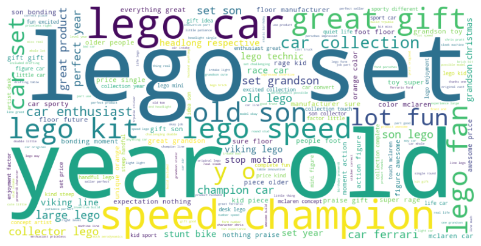

```python
from collections import Counter
from wordcloud import WordCloud
import matplotlib.pyplot as plt

# Combine all nouns and adjectives into a single string
all_nouns_adjs = ' '.join(reviews_df['Nouns_adjs'])

# Count the frequency of each word
word_freq = Counter(all_nouns_adjs.split())

# Display the top 20 most common nouns/adjectives
common_nouns_adjs = word_freq.most_common(20)
print("Top 20 Most Common Nouns and Adjectives:", common_nouns_adjs)

# Generate a WordCloud for visualization
wordcloud = WordCloud(width=800, height=400, background_color='white').generate(all_nouns_adjs)
plt.figure(figsize=(10, 5))
plt.imshow(wordcloud, interpolation='bilinear')
plt.axis('off')
plt.show()
```

### 2. Which dates have the highest number of reviews?

```python
# Group by Cleaned_Date and count the reviews
date_review_counts = review_df.groupby('Cleaned_Date').size()

# Sort by descending order to get the dates with the highest number of reviews
highest_review_dates = date_review_counts.sort_values(ascending=False).head(10)

# Display the result
print("Dates with the highest number of reviews:")
print(highest_review_dates)
```

```
Dates with the highest number of reviews:
Cleaned_Date
2005-10-19    35
2008-06-08    35
2018-11-07    35
2019-03-17    35
2019-04-23    35
2019-04-29    35
2019-05-15    35
2019-07-12    35
2019-07-31    35
2019-09-04    35
dtype: int64
```

### 3. What are the common themes found in the reviews?

```python
# Get the top reviewers
top_reviewers = reviews_df['Customer'].value_counts().head(10).index

# Filter reviews from top reviewers
top_reviewer_reviews = reviews_df[reviews_df['Customer'].isin(top_reviewers)]

# Combine all nouns and adjectives for top reviewers
top_reviewer_nouns_adjs = ' '.join(top_reviewer_reviews['Nouns_adjs'])

# Most common words from top reviewers
top_reviewer_word_freq = Counter(top_reviewer_nouns_adjs.split())
common_words_top_reviewers = top_reviewer_word_freq.most_common(20)
print("Top Words from Most Active Reviewers:", common_words_top_reviewers)
```

```
Top Words from Most Active Reviewers: [('lego', 945), ('set', 665), ('car', 350), ('year', 245), ('old', 245), ('bike', 245), ('son', 210), ('price', 210), ('fun', 210), ('little', 210), ('time', 210), ('more', 175), ('grandson', 175), ('piece', 175), ('gift', 175), ('great', 175), ('toy', 140), ('k…
```

### 4. Which LEGO products were highest rated?

```python
# Sort the reviews by Ratings in descending order
highest_rated = reviews_df.sort_values(by='Ratings', ascending=False)

# Show the top 10 highest-rated products
highest_rated_top_10 = highest_rated[['Product_url', 'Ratings']].head(10)
print(highest_rated_top_10)
```

```
                                                                                          Product_url  \
0                          https://www.amazon.com/Lego-Kristoffs-Sleigh-Adventure-41066/dp/B012NOL0ZE
1132  https://www.amazon.com/Eiffel-Figurine-Artwork-Collectors-%C3%AF%C2%BC%CB%86Black/dp/B00NVDJ7G6
1130  https://www.amazon.com/Eiffel-Figurine-Artwork-Collectors-%C3%AF%C2%BC%CB%86Black/dp/B00NVDJ7G6
1129               https://www.amazon.com/LEGO-Jurassic-Triceratops-Velociraptor-391pcs/dp/B0CKL2XPJL
1128               https://www.amazon.com/LEGO-Jurassic-Triceratops-Velociraptor-391pcs/dp/B0CKL2XPJL
1127               https://www.amazon.com/LEGO-Jurassic-Triceratops-Velociraptor-391pcs/dp/B0CKL2XPJL
1126               https://www.amazon.com/LEGO-Jurassic-Triceratops-Velociraptor-391pcs/dp/B0CKL2XPJL
1125               https://www.amazon.com/LEGO-Jurassic-Triceratops-Velociraptor-391pcs/dp/B0CKL2XPJL
1124               https://www.amazon.com/LEGO-Jurassic-Triceratops-Velociraptor-391pcs/dp/B0CKL2XPJL
1123               https://www.amazon.com/LEGO-Jurassic-Triceratops-Velociraptor-391pcs/dp/B0CKL2XPJL

      Ratings
0           5
1132        5
1130        5
1129        5
1128        5
1127        5
1126        5
1125        5
1124        5
1123        5
```

```python
# Group by Product_url and calculate the average rating for each product
average_ratings = reviews_df.groupby('Product_url')['Ratings'].mean()

# Sort by average rating in descending order to find the highest-rated products
highest_rated_products = average_ratings.sort_values(ascending=False)

# Extract the part of the URL after "amazon.com/"
highest_rated_products.index = highest_rated_products.index.str.split('amazon.com/').str[1].str.split('/').str[0]

# Show the top 10 highest-rated products
highest_rated_products.head(10)
```

```
Product_url
LEGO-Jurassic-Triceratops-Velociraptor-391pcs                 5.000000
LEGO-Lego-40596-Magic-Maze                                    5.000000
Lego-Kristoffs-Sleigh-Adventure-41066                         5.000000
LEGO-75880-Champions-McLaren-Building                         4.875000
LEGO-Technic-WHACK-42072-Building                             4.875000
Eiffel-Figurine-Artwork-Collectors-%C3%AF%C2%BC%CB%86Black    4.750000
LEGO-8632-Agents-Swamp-Raid                                   4.500000
LEGO-Ultra-Agents-70164-Hurricane                             4.500000
LEGO-Stories-Action-Vikings-Challenges                        4.333333
LEGO-3-Pack-Action-Figure-66778                               4.000000
Name: Ratings, dtype: float64
```

### 5. What is the average rating of LEGO sets in different periods?

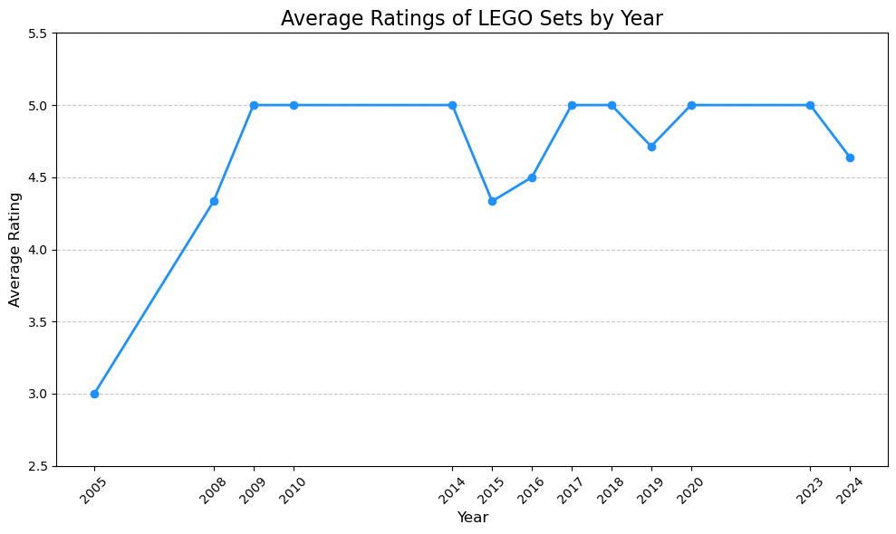

```python
import matplotlib.pyplot as plt

# Group by Year and calculate average Ratings
average_ratings_by_year = review_df.groupby('Year')['Ratings'].mean()

# Plot the line chart
plt.figure(figsize=(10, 6))
plt.plot(average_ratings_by_year.index, average_ratings_by_year, marker='o', linestyle='-', color='dodgerblue', linewidth=2)

# Add title and labels
plt.title("Average Ratings of LEGO Sets by Year", fontsize=16)
plt.xlabel("Year", fontsize=12)
plt.ylabel("Average Rating", fontsize=12)
plt.xticks(ticks=average_ratings_by_year.index, rotation=45)  # Ensure proper alignment of years
plt.ylim(2.5, 5.5)  # Assuming ratings are on a scale of 0-5
plt.grid(axis='y', linestyle='--', alpha=0.7)

# Add layout adjustment to prevent label cutoff
plt.tight_layout()

# Show the plot
plt.show()
```

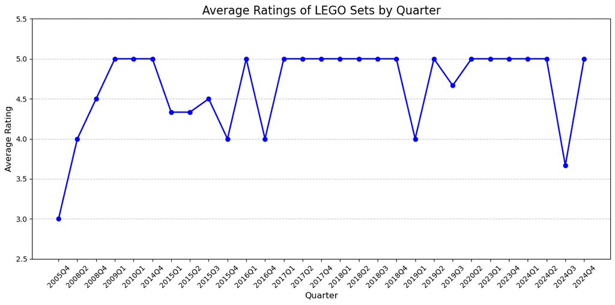

```python
import matplotlib.pyplot as plt

# Group by Quarter and calculate average Ratings
average_ratings_by_quarter = review_df.groupby('Quarter')['Ratings'].mean()

# Convert Quarter to string for better axis labeling
average_ratings_by_quarter.index = average_ratings_by_quarter.index.astype(str)

# Plot the line chart
plt.figure(figsize=(12, 6))
plt.plot(average_ratings_by_quarter.index, average_ratings_by_quarter, marker='o', color='blue', linestyle='-', linewidth=2)

# Add title and labels
plt.title("Average Ratings of LEGO Sets by Quarter", fontsize=16)
plt.xlabel("Quarter", fontsize=12)
plt.ylabel("Average Rating", fontsize=12)
plt.xticks(rotation=45)
plt.ylim(2.5, 5.5)  # Assuming ratings are on a scale of 0-5
plt.grid(axis='y', linestyle='--', alpha=0.7)

# Show the plot
plt.tight_layout()
plt.show()
```

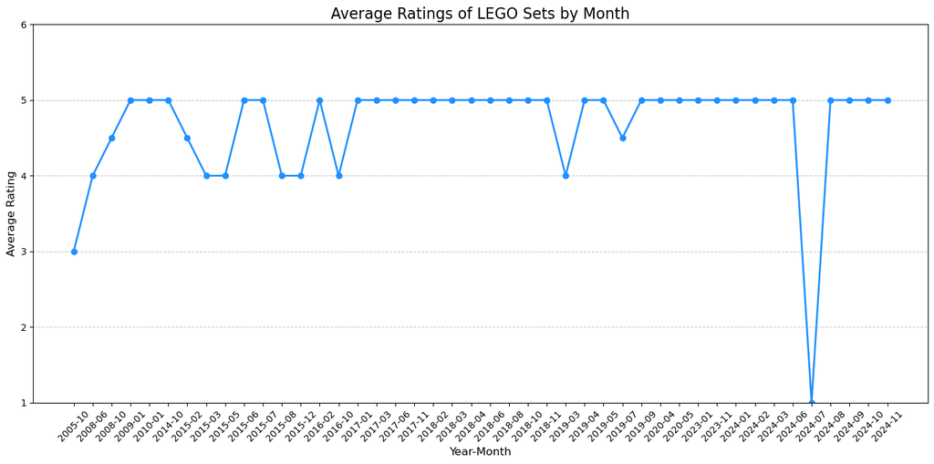

```
Average Ratings by Month:
Year_Month
2005-10    3.0
2008-06    4.0
2008-10    4.5
2009-01    5.0
2010-01    5.0
2014-10    5.0
2015-02    4.5
2015-03    4.0
2015-05    4.0
2015-06    5.0
2015-07    5.0
2015-08    4.0
2015-12    4.0
2016-02    5.0
2016-10    4.0
2017-01    5.0
2017-03    5.0
2017-06    5.0
2017-11    5.0
2018-02    5.0
2018-03    5.0
2018-04    5.0
2018-06    5.0
2018-08    5.0
2018-10    5.0
2018-11    5.0
2019-03    4.0
2019-04    5.0
2019-05    5.0
2019-07    4.5
2019-09    5.0
2020-04    5.0
2020-05    5.0
2023-01    5.0
2023-11    5.0
2024-01    5.0
2024-02    5.0
2024-03    5.0
2024-06    5.0
2024-07    1.0
2024-08    5.0
2024-09    5.0
2024-10    5.0
2024-11    5.0
Freq: M, Name: Ratings, dtype: float64
```

```python
# Add a Year-Month column
review_df['Year_Month'] = review_df['Cleaned_Date'].dt.to_period('M')
import matplotlib.pyplot as plt

# Convert Year_Month to string for better axis labeling
average_ratings_by_month.index = average_ratings_by_month.index.astype(str)

# Plot the line chart
plt.figure(figsize=(14, 7))
plt.plot(average_ratings_by_month.index, average_ratings_by_month, marker='o', linestyle='-', color='dodgerblue', linewidth=2)

# Add title and labels
plt.title("Average Ratings of LEGO Sets by Month", fontsize=16)
plt.xlabel("Year-Month", fontsize=12)
plt.ylabel("Average Rating", fontsize=12)
plt.xticks(rotation=45, fontsize=10)  # Rotate x-axis labels for better readability
plt.ylim(1, 6)  # Assuming ratings are on a scale of 0-5
plt.grid(axis='y', linestyle='--', alpha=0.7)

# Add a layout to prevent label cutoff
plt.tight_layout()

# Show the plot
plt.show()

# Group by Year-Month and calculate average Ratings
average_ratings_by_month = review_df.groupby('Year_Month')['Ratings'].mean()

print("Average Ratings by Month:")
print(average_ratings_by_month)
```

### 6. Who are the most active reviewers?

```
Top 10 Most Active Reviewers:
 Customer
Amazon Customer              490
                             210
Nancy CA                      70
LEGO Technic WHACK! 42072     35
@hibbisonmike                 35
31 for 2                      35
Mark                          35
Melissa S. Watson             35
maureen "MOE"                 35
Holly H                       35
Name: count, dtype: int64
```

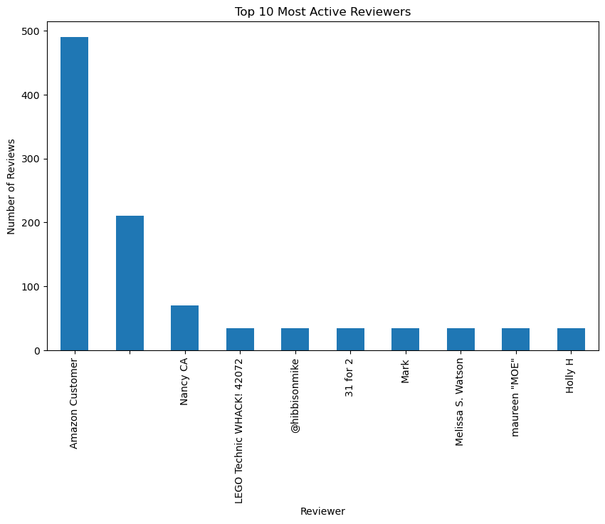

```python
# Count reviews by each customer
top_reviewers = reviews_df['Customer'].value_counts().head(10)

# Display the most active reviewers
print("Top 10 Most Active Reviewers:\n", top_reviewers)

# Visualize the top reviewers (optional)
top_reviewers.plot(kind='bar', figsize=(10, 6), title="Top 10 Most Active Reviewers")
plt.xlabel("Reviewer")
plt.ylabel("Number of Reviews")
plt.show()
```

### 7. What is the proportion of very positive or negative reviews?

```python
# Define thresholds for very positive and very negative reviews
positive_threshold = 4.5
negative_threshold = 2.5

# Filter very positive and very negative reviews
very_positive = review_df[review_df['Ratings'] >= positive_threshold]
very_negative = review_df[review_df['Ratings'] <= negative_threshold]

# Calculate proportions
total_reviews = len(reviews_df)
proportion_positive = len(very_positive) / total_reviews * 100
proportion_negative = len(very_negative) / total_reviews * 100

# Display the results
print(f"Proportion of Very Positive Reviews: {proportion_positive:.2f}%")
print(f"Proportion of Very Negative Reviews: {proportion_negative:.2f}%")
```

```
Proportion of Very Positive Reviews: 76.92%
Proportion of Very Negative Reviews: 1.92%
```

## Part 4: NLP Analysis

```python
from sklearn.feature_extraction.text import TfidfVectorizer
from sklearn.feature_extraction.text import CountVectorizer
from sklearn.pipeline import make_pipeline
```

### Method 1: sklearn NMF model

```python
from sklearn.decomposition import NMF
from sklearn.feature_extraction.text import TfidfVectorizer
from sklearn.pipeline import make_pipeline

# Replace NaN values in the "Nouns_adjs" column with an empty string
review_df["Nouns_adjs"] = review_df["Nouns_adjs"].fillna("")

# Set up the topic modeling pipeline using NMF
nmf_model = make_pipeline(
    TfidfVectorizer(),
    NMF(n_components=10, random_state=0, init="nndsvd")
)

# Train the model using the preprocessed data
NMF_result = nmf_model.fit_transform(review_df["Nouns_adjs"])

# Extract components and feature names
nmf = nmf_model.named_steps['nmf']
tfidf = nmf_model.named_steps['tfidfvectorizer']
feature_names = tfidf.get_feature_names_out()

# Define the number of top words to extract for each topic
n_top_words = 10
topic_keywords = {}

# Get the top words for each topic
for topic_idx, topic in enumerate(nmf.components_):
    top_features_idx = topic.argsort()[-n_top_words:][::-1]
    top_features = [feature_names[i] for i in top_features_idx]
    topic_keywords[f"Topic {topic_idx}"] = top_features

# Display the top words for each topic
print("Top 10 topics for 'reviews[Nouns_adjs]': \n")
for topic, keywords in topic_keywords.items():
    print(f"{topic}: {', '.join(keywords)}")
```

```
Top 10 topics for 'reviews[Nouns_adjs]':

Topic 0: car, lego, other, speed, collection, kit, much, real, anything, champion
Topic 1: son, year, old, quality, set, type, that, hour, school, racecar
Topic 2: grandson, christmas, birthday, one, static, present8, bought, swamp, type, perfect
Topic 3: gift, fan, christmas, moment, action, bonding, figure, recipient, awesome, great
Topic 4: good, night, yard, shipping, value, decor, solar, time, quality, light
Topic 5: set, lego, viking, time, cool, many, building, line, happy, biggest
Topic 6: product, perfect, great, thanks, seller, place, correct, trpuble, ferrari, everything
Topic 7: bike, something, side, minifig, boy, stunt, motor, bridge, kid, controlled
Topic 8: price, single, worth, look, man, face, evening, fan, toy, little
Topic 9: agent, lot, fun, hard, more, adventure, one, story, piece, that
```

### Method 2: Gensim NMF model

```python
from gensim.corpora import Dictionary
from gensim.models import Nmf
from gensim.matutils import Sparse2Corpus
from nltk.tokenize import word_tokenize

# doc2bow expects an array of unicode tokens
# we didn't clean the reviews
token_list = [word_tokenize(review) for review in review_df["Nouns_adjs"]]

# Create a dictionary representation of the documents
dictionary = Dictionary(token_list)

# Convert document into the bag-of-words (BoW) format
corpus = [dictionary.doc2bow(text) for text in token_list]

# Build the NMF model
nmf_gensim = Nmf(corpus=corpus, num_topics=10,
                id2word=dictionary, # convert the word id into word itself
                random_state=0)

# Print the top 10 words for each topic
print("Top 10 topics for 'reviews[Nouns_adjs]' using Gensim model: \n")

topics = nmf_gensim.print_topics(num_words=10)

for index, topic in enumerate(topics):
    print(f"Topic {index}: {topic}")
```

```
Top 10 topics for 'reviews[Nouns_adjs]' using Gensim model:

Topic 0: (0, '0.040*"line" + 0.037*"part" + 0.035*"car" + 0.027*"lego" + 0.026*"intake" + 0.023*"champion" + 0.021*"real" + 0.020*"great" + 0.019*"speed" + 0.019*"light"')
Topic 1: (1, '0.105*"lego" + 0.094*"set" + 0.031*"son" + 0.021*"kid" + 0.018*"kit" + 0.015*"other" + 0.014*"y.o" + 0.013*"age" + 0.013*"friend" + 0.013*"fun"')
Topic 2: (2, '0.041*"little" + 0.039*"car" + 0.037*"stop" + 0.034*"more" + 0.028*"set" + 0.025*"motion" + 0.022*"lego" + 0.020*"grandson" + 0.017*"champion" + 0.015*"lot"')
Topic 3: (3, '0.047*"good" + 0.042*"product" + 0.028*"stop" + 0.023*"set" + 0.019*"motion" + 0.018*"piece" + 0.016*"agent" + 0.016*"year" + 0.016*"old" + 0.015*"lot"')
Topic 4: (4, '0.037*"son" + 0.022*"end" + 0.022*"bit" + 0.021*"build" + 0.020*"y.o" + 0.019*"tough" + 0.019*"technic" + 0.016*"original" + 0.016*"something" + 0.014*"real"')
Topic 5: (5, '0.102*"bike" + 0.049*"minifig" + 0.049*"side" + 0.036*"something" + 0.033*"bridge" + 0.033*"cool" + 0.021*"fun" + 0.019*"lego" + 0.017*"nice" + 0.017*"y.o"')
Topic 6: (6, '0.101*"car" + 0.036*"lego" + 0.034*"other" + 0.033*"price" + 0.030*"great" + 0.025*"gift" + 0.021*"year" + 0.020*"mclaren" + 0.019*"old" + 0.019*"figure"')
Topic 7: (7, '0.056*"lego" + 0.042*"gift" + 0.030*"little" + 0.027*"great" + 0.020*"car" + 0.018*"child" + 0.018*"piece" + 0.016*"technics" + 0.016*"light" + 0.015*"box"')
Topic 8: (8, '0.033*"easy" + 0.031*"cycle" + 0.031*"base" + 0.024*"car" + 0.023*"swamp" + 0.019*"headlong" + 0.019*"agent" + 0.019*"respective" + 0.019*"construction" + 0.017*"front"')
Topic 9: (9, '0.064*"viking" + 0.058*"lego" + 0.051*"set" + 0.032*"time" + 0.031*"fan" + 0.023*"new" + 0.019*"line" + 0.017*"dragon" + 0.014*"same" + 0.014*"deal"')
```

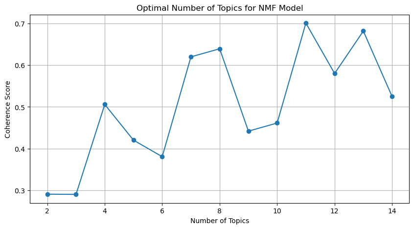

```python
from gensim.models.coherencemodel import CoherenceModel
import matplotlib.pyplot as plt
%matplotlib inline

# create an empty list to save different coherence scores
coherence_scores = []

for num in range(2, 15):
    # build the NMF model using the different number of topics
    nmf_gensim = Nmf(corpus=corpus,
                       num_topics=num,
                       id2word=dictionary, # convert the word id into word itself
                       random_state=0)

    coherence_model = CoherenceModel(model=nmf_gensim, texts=token_list, dictionary=dictionary, coherence='c_v')

    coherence_scores.append(coherence_model.get_coherence())

plt.figure(figsize=(10, 5))
plt.plot(range(2, 15), coherence_scores, marker='o')
plt.title("Optimal Number of Topics for NMF Model")
plt.xlabel("Number of Topics")
plt.ylabel("Coherence Score")
plt.grid(True)
```

## Part 4: Visualization Graph [TF-IDF]

```python
from sklearn.feature_extraction.text import TfidfVectorizer

tfidfVectorizer=TfidfVectorizer(use_idf=True) # default is True. False means TF only
```

```python
# we can use the same tfidfVectorizer
tfidf_matrix_lab = tfidfVectorizer.fit_transform(review_df["Nouns_adjs"])

# Create a DataFrame with the TF-IDF scores
tfidf_df_lab = pd.DataFrame(tfidf_matrix_lab[0].T.toarray(), index=tfidfVectorizer.get_feature_names_out(), columns=["TF-IDF"])

tfidf_df_lab = tfidf_df_lab.sort_values('TF-IDF', ascending=False)
tfidf_df_lab[:30]
```

|  | TF-IDF |
| --- | --- |
| item | 0.47024 |
| expectation | 0.47024 |
| nothing | 0.47024 |
| praise | 0.47024 |
| more | 0.33985 |
| 14 | 0.00000 |
| preció | 0.00000 |
| project | 0.00000 |
| product | 0.00000 |
| problem | 0.00000 |
| priceless | 0.00000 |
| price | 0.00000 |
| pretty | 0.00000 |
| present8 | 0.00000 |
| pratt | 0.00000 |
| proportion | 0.00000 |
| possible | 0.00000 |
| porsches | 0.00000 |
| plus | 0.00000 |
| pleased | 0.00000 |
| playing | 0.00000 |
| playful | 0.00000 |
| planning | 0.00000 |
| place | 0.00000 |
| piece | 0.00000 |
| perfect | 0.00000 |
| people | 0.00000 |
| propeller | 0.00000 |
| proud | 0.00000 |
| propulsion | 0.00000 |

```
(-0.5, 399.5, 199.5, -0.5)
```

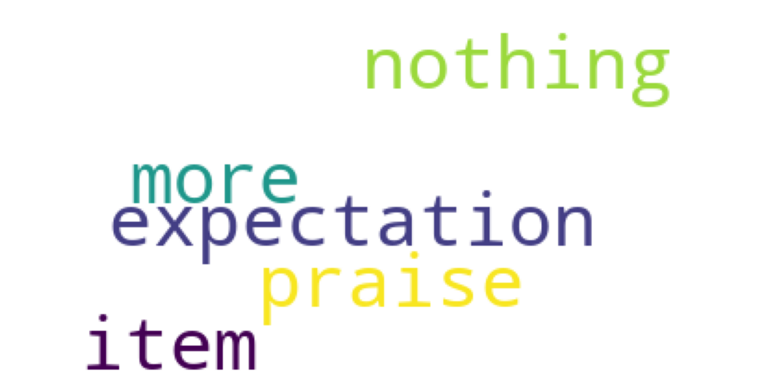

```python
# Generate the word cloud using the bigram scores
wordcloud = WordCloud(max_font_size=40, relative_scaling=.1, background_color='white')
# NOTICE: here is .generate_from_frequencies() from the TFIDF scores (numbers)
wordcloud.generate_from_frequencies(tfidf_df_lab["TF-IDF"])

# Display the word cloud
plt.figure(figsize=(12, 12))
plt.imshow(wordcloud)
plt.axis('off')
```

```python
# Initialize TfidfVectorizer to consider only bigrams
tfidfVectorizer_bigram = TfidfVectorizer(ngram_range=(2, 2))

# Fit and transform the documents
tfidf_matrix_bigram = tfidfVectorizer_bigram.fit_transform(review_df["Nouns_adjs"])

# Convert the TF-IDF matrix to a DataFrame for easier viewing
tfidf_df_bigram = pd.DataFrame(tfidf_matrix_bigram[0].T.toarray(), index=tfidfVectorizer_bigram.get_feature_names_out(), columns=["TF-IDF"])

tfidf_df_bigram = tfidf_df_bigram.sort_values('TF-IDF', ascending=False)
tfidf_df_bigram[:30]
```

|  | TF-IDF |
| --- | --- |
| item more | 0.5 |
| nothing praise | 0.5 |
| expectation nothing | 0.5 |
| more expectation | 0.5 |
| 14 age | 0.0 |
| perfect year | 0.0 |
| part set | 0.0 |
| part use | 0.0 |
| particular set | 0.0 |
| passionate collector | 0.0 |
| people foot | 0.0 |
| perfect product | 0.0 |
| perfect seller | 0.0 |
| piece backward | 0.0 |
| pair le | 0.0 |
| piece biggest | 0.0 |
| piece box | 0.0 |
| piece little | 0.0 |
| piece older | 0.0 |
| place other | 0.0 |
| planning combination | 0.0 |
| playful abuse | 0.0 |
| playing real | 0.0 |
| part good | 0.0 |
| own child | 0.0 |
| plus bc | 0.0 |
| original lego | 0.0 |
| old ton | 0.0 |
| older people | 0.0 |
| one grandson | 0.0 |

```
(-0.5, 399.5, 199.5, -0.5)
```

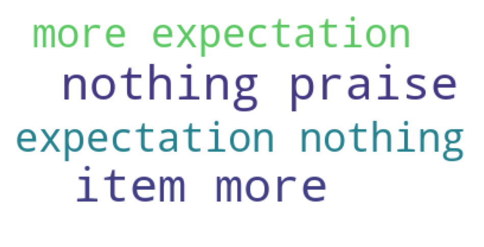

```python
# Generate the word cloud using the bigram scores
wordcloud = WordCloud(max_font_size=40, relative_scaling=.1, background_color='white')
# NOTICE: here is .generate_from_frequencies() from the TFIDF scores (numbers)
wordcloud.generate_from_frequencies(tfidf_df_bigram["TF-IDF"])

# Display the word cloud
plt.figure(figsize=(12, 12))
plt.imshow(wordcloud)
plt.axis('off')
```

```
(-0.5, 3839.5, 2159.5, -0.5)
```

[figure not shown]

```python
import numpy as np
from PIL import Image # Pillow library (PIL)
import requests
from io import BytesIO

# step 1: get the URL of the image
image_url = "https://1000logos.net/wp-content/uploads/2021/04/Lego-logo.png" # this is an Owala logo image

# step 2: fetch the image from the website
response = requests.get(image_url)

# step 3: load the image with Pillow library (PIL)
# this provides a file-like interface for reading and writing bytes objects not a simply string
img = Image.open(BytesIO(response.content))

# step 4: convert the image to grayscale because the mask operates based on lightness values.
# The word cloud generation process uses the mask to determine where to place words:
# typically, words are placed in the darker areas (or the non-white areas if you invert the mask).
img = img.convert('L')

# step 5: convert the image to a numpy array
# if you are using a local image you can directly set mask = np.array(Image.open(file path))
mask = np.array(img)

# step 6: generate word cloud map with mask
wordcloud = WordCloud(relative_scaling=.1,
                      background_color="white",
                      mask=mask, # set up the mask parameter
                      contour_width=1, contour_color='purple' # set up the image border lines and color
                     )
wordcloud.generate_from_frequencies(tfidf_df_bigram["TF-IDF"])

# step 7: display the word cloud
plt.figure(figsize=(12, 12))
plt.imshow(wordcloud)
plt.axis("off")
```

## Part 5: Conclusion-Business Questions

#### Distribution of Overall Ratings:

Most reviews are rated high, indicating customer satisfaction with the LEGO products.

#### Common Themes in Reviews:

The reviews have mostly identified LEGO sets as very good gifts for boys and use keywords like cars, bikes, sons, and grandsons. The general adjectives used are "fun," "great," and "good." From the data, there is a high tendency toward boys' products.

#### Dates with the Highest Reviews:

Specific dates like 2005-10-19, 2008-06-08, and others have a maximum of 35 reviews, likely due to Amazon's review limits per product per day.

#### Highest Rated LEGO Products:

2005 had the lowest average ratings, likely due to limited internet access at the time and reviews skewing negative due to effortful posting. The average ratings suddenly dropped in 2024 Q3, which was contributed by the anomaly in July 2024, when ratings were as low as 1. Most Active Reviewers: The most active reviewers include "Amazon Customer" with 490 reviews and a few others who reviewed 35 products. Many customers prefer anonymity when sharing reviews.

#### Proportion of Positive/Negative Reviews:

Very Positive Reviews: 76.92% Very Negative Reviews: 1.92%

## Part 6: Conclusion-NLP Analysis

### Common Themes in Reviews:

1. Reviews focus heavily on cars, Lego sets, and action-oriented items. Words like "son," "grandson," and "gift" indicate that many products are purchased for children, particularly boys, as gifts for birthdays, Christmas, and other occasions.
2. Other common themes include building experiences ("time," "building," "cool") and quality/value of the products ("good," "price," "great").

### Topic Analysis Insights:

1. The result of the manual and Gensim-based topic modeling reveals that most topics have the emphasis on cars, bikes, Technic sets, and gifts. They all fall within product-specific features and purchase motivation.
2. Gensim had further clarification of such topics as:
- Topic 1: Lego sets for kids and general enjoyment.
- Topic 5: Bike and minifigures often connect with action-oriented themes.
- Topic 9: Fans and Vikings could connect with nostalgic themes or themed sets.

### Best Topic Count

The best number of topics for the NMF model is 11, reflecting a wide variety of interests, product types, and user preferences.

### General Observations on Data Bias:

1. The dataset is biased toward products for boys and maintains traditional gender roles in toys, such as cars, bikes, and Vikings.
2. Positive sentiment is dominant, with 76.92% of the reviews being very positive.

### Possible Limitations:

1. Repetitiveness in top themes: Many topics are similar because the dataset focuses on Lego-related products.
2. Gender bias: Reviews seem heavily focused on products for boys, possibly underrepresenting items popular among other demographics.